# 2018-11-15 qbic test 2

Theresa Swayne

11/15/2018

## Changes to improve nuclei detection

From the previous test we proposed:

1. Instead of a mask, save more specific documentation of the particles CP detected
2. Find out if the additional particles CP detects are the source of the low intensities
3. Figure out how to filter the particles to limit to legitimate nuclei – suppress unwanted divisions.

Because Test 1 produced a good mask but a lot of low-intensity object detections, I suspected that nuclei were being split into separate objects. To prevent this, the splitting function was turned off entirely.

To prevent false positives in empty fields, a minimum threshold setting of 0.01 (relative to image intensity) was used.

## Testing nuclear detection and DNA content analysis

The background-corrected integrated intensity (“total intensity”) of nuclei should be proportional to DNA content.

The DNA content in a mixed population of actively cycling cells should form a roughly bimodal distribution representing 1N and 2N populations, with some intermediate cells in S phase.

CellProfiler pipelines were used to perform background correction, identify nuclei using DAPI, and measure intensity of DAPI and other channels in a set of 100 images collected on 11-5-2018.

Reading the data from CellProfiler, we focus on the corrected integrated intensity from Channel 1, DAPI:

```r
qbic_C1DNANuclei <- read_csv("~/Desktop/output/qbic_C1DNANuclei.csv")
#dnaTotalInt <- qbic_C1DNANuclei$Intensity_IntegratedIntensity_Channel1DNA
dnaTotalInt <- qbic_C1DNANuclei$Intensity_IntegratedIntensity_Channel1DNACorr
```

Plotting a histogram of the DNA content over all 922 nuclei detected:

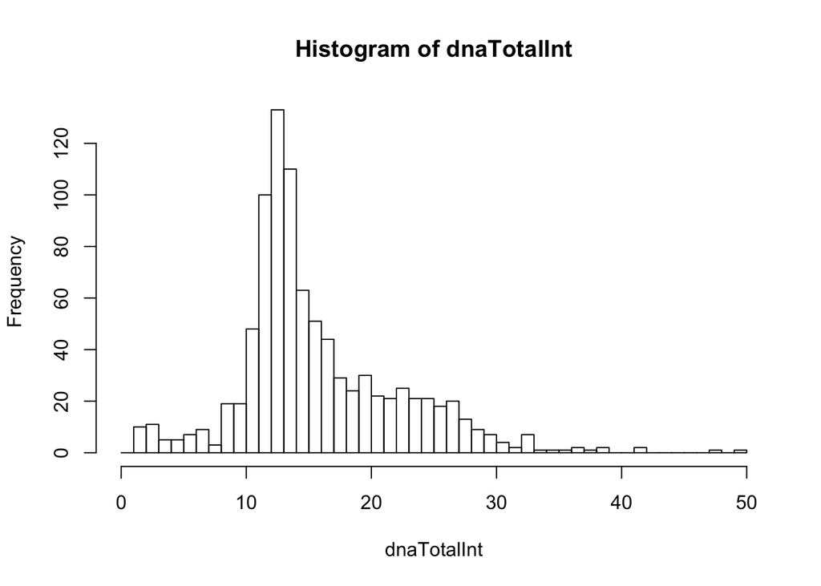

```r
# use echo=FALSE to prevent printing code
hist(dnaTotalInt, breaks = (0:50))
```

This shows that there is a roughly bimodal distribution with peaks ~ 12 and ~ 24, with tails on either side. Compared to test 1, the objects with very low intensity have been essentially eliminated.

```r
low_vals <- mean(dnaTotalInt < 1)
high_vals <- mean(dnaTotalInt > 30)
central_vals <- mean(dnaTotalInt > 1 & dnaTotalInt < 30)

cat(central_vals, "of the values are between 1 and 30; ",low_vals,"<1; and",high_vals,">30")
```

```
## 0.972885 of the values are between 1 and 30;  0 <1; and 0.02711497 >30
```

Ultimately we would like to see an inverted horseshoe-type plot of EdU (showing S phase cells) vs. DNA content where the cells incorporating EdU are primarily those between the 2 peaks.

Generating the other dimension of the plot from the corrected mean intensity from Channel 2, EdU:

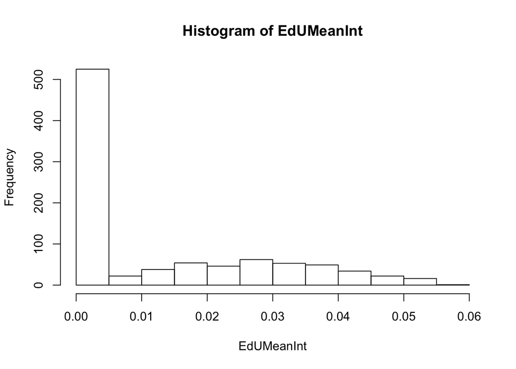

```r
#EdUMeanInt <- qbic_C1DNANuclei$Intensity_MeanIntensity_Channel2EdU
EdUMeanInt <- qbic_C1DNANuclei$Intensity_MeanIntensity_Channel2EdUCorr
hist(EdUMeanInt)
```

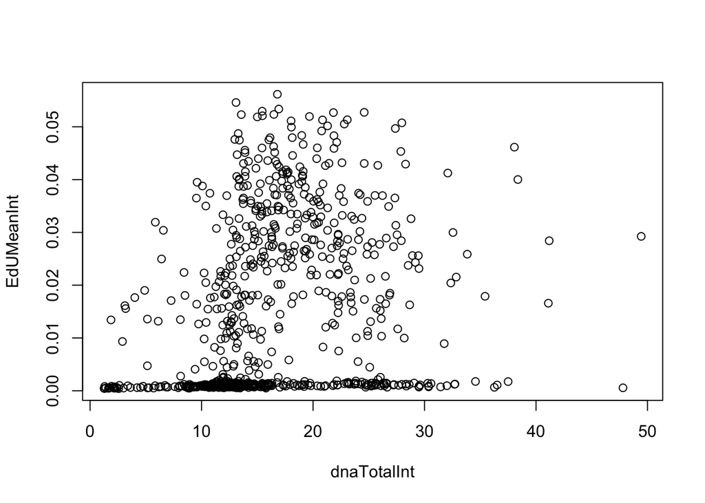

```r
plot(x = dnaTotalInt, y = EdUMeanInt) # basic scatter plot
```

The horseshoe shape might be starting to emerge.

### Are nuclei detected properly?

Revisiting the 10 randomly selected images we checked in test 1:

The previous mask matched the visible nuclei very well, so for convenience we can compare the CP object detections to the Analyze Particles detections based on the original mask.

```r
qbic_check <- read_csv("~/Desktop/2018-11-05 Demis/2018-11-15 qbic test 2.csv")
kable(qbic_check[,c(1,2,5)])
```

| Image | Cells detected by CP | Cells detected by Analyze Particles |
| --- | --- | --- |
| 89 | 9 | 9 |
| 51 | 11 | 11 |
| 68 | 15 | 16 |
| 85 | 8 | 9 |
| 31 | 12 | 13 |
| 65 | 3 | 3 |
| 36 | 9 | 9 |
| 45 | 0 | 39 |
| 13 | 11 | 11 |
| 86 | 8 | 8 |